# ggstackplot

## `overlap` argument

Overlap determines the grid overlap between the multiple stacked plots. `1` corresponds to fully overlapping (similar to having a ggplot `sec_axis` enabled) while `0` does not overlap at all.

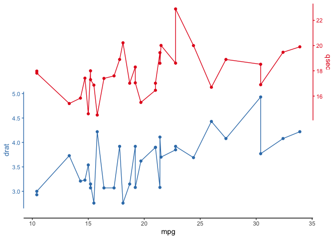

```r
# define any overlap between 0 and 1
mtcars |>
  ggstackplot(
    x = mpg, y = c(qsec, drat),
    color = c("#E41A1C", "#377EB8"),
    overlap = 0.3
  )
```

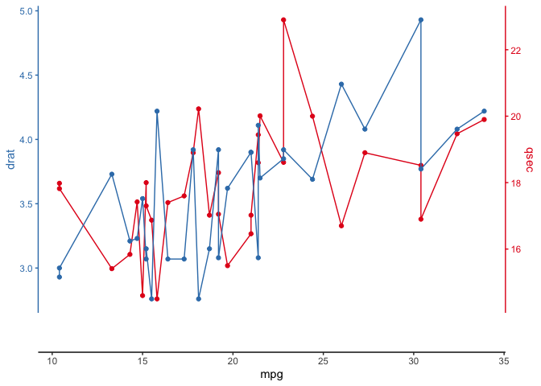

```r
# full overlap
mtcars |>
  ggstackplot(
    x = mpg, y = c(qsec, drat),
    color = c("#E41A1C", "#377EB8"),
    overlap = 1
  )
```

### Different overlaps

Multiple overlap arguments can be supplied with a numeric vector of numbers between 0 and 1, where each element in the vector corresponds to the overlap between the *n* and *n+1*th overlap value. For example, for a plot with four stacked panels: `qsec`, `drat`, `wt`, `hp`, a vector of `overlap = c(1, 0, 1)` indicates that between the first 2 elements (`qsec` and `drat`) there is full overlap. Between `drat` and `wt` there is no overlap (`0`). Between `wt` and `hp` there is full overlap.

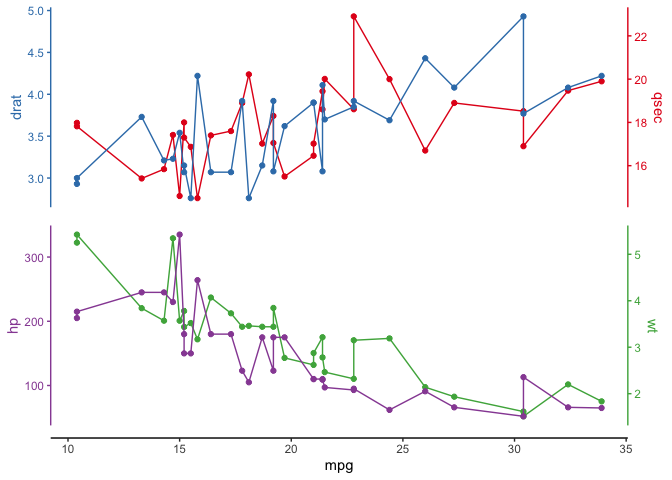

```r
# different overlap between stack panels
mtcars |>
  ggstackplot(
    x = mpg,
    y = c(qsec, drat, wt, hp),
    color = c("#E41A1C", "#377EB8", "#4DAF4A", "#984EA3"),
    overlap = c(1, 0, 1)
  )
```

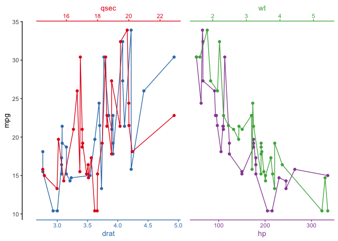

```r
# and the horizontal version
mtcars |>
  ggstackplot(
    y = mpg,
    x = c(qsec, drat, wt, hp),
    color = c("#E41A1C", "#377EB8", "#4DAF4A", "#984EA3"),
    overlap = c(1, 0, 1)
  )
```